# Final Project Submission

Wesley Lim

2022-11-20

This dataset deals with untidy, raw data for recording global plastic pollution. [https://github.com/rfordatascience/tidytuesday/blob/master/data/2021/2021-01-26/readme.md] This data set contains data about global plastic pollution in the years 2019-2020. The data can be categorized by plastic type, country of cleanup, and source of plastic. While the data isn’t necessarily an accurate representative of plastic pollution, it can give a glimpse into the situation given increasing environmental concerns.

In this project, I aimed to use R to tidy up the data and present statistical tests and graphical representations. At the same time, I attempted to learn python and use its PANDAS package to perform the same tasks if available.

Here, I loaded the dataset and got a sense of what I am working with. Verrry untidy data at first glance.

```r
## R
plastics <- readr::read_csv('https://raw.githubusercontent.com/rfordatascience/tidytuesday/master/data/2021/2021-01-26/plastics.csv')
glimpse(plastics)
```

```
## Rows: 13,380
## Columns: 14
## $ country        <chr> "Argentina", "Argentina", "Argentina", "Argentina", "Ar…
## $ year           <dbl> 2019, 2019, 2019, 2019, 2019, 2019, 2019, 2019, 2019, 2…
## $ parent_company <chr> "Grand Total", "Unbranded", "The Coca-Cola Company", "S…
## $ empty          <dbl> 0, 0, 0, 0, 0, 0, 0, 0, 0, 0, 0, 0, 0, 0, 0, 0, 0, 0, 0…
## $ hdpe           <dbl> 215, 155, 0, 0, 0, 0, 0, 0, 0, 0, 0, 0, 0, 0, 0, 0, 0, …
## $ ldpe           <dbl> 55, 50, 0, 0, 0, 0, 0, 0, 0, 0, 0, 0, 0, 0, 0, 0, 0, 0,…
## $ o              <dbl> 607, 532, 0, 0, 0, 0, 0, 0, 0, 0, 0, 0, 0, 13, 0, 0, 0,…
## $ pet            <dbl> 1376, 848, 222, 39, 38, 22, 21, 26, 19, 14, 14, 14, 14,…
## $ pp             <dbl> 281, 122, 35, 4, 0, 7, 6, 0, 1, 4, 3, 1, 0, 0, 3, 0, 4,…
## $ ps             <dbl> 116, 114, 0, 0, 0, 0, 0, 0, 0, 0, 0, 0, 0, 0, 0, 0, 0, …
## $ pvc            <dbl> 18, 17, 0, 0, 0, 0, 0, 0, 0, 0, 0, 0, 0, 0, 0, 0, 0, 0,…
## $ grand_total    <dbl> 2668, 1838, 257, 43, 38, 29, 27, 26, 20, 18, 17, 15, 14…
## $ num_events     <dbl> 4, 4, 4, 4, 4, 4, 4, 4, 4, 4, 4, 4, 4, 4, 4, 4, 4, 4, 4…
## $ volunteers     <dbl> 243, 243, 243, 243, 243, 243, 243, 243, 243, 243, 243, …
```

```python
## Python
import pandas as pd
plastics = pd.read_csv('https://raw.githubusercontent.com/rfordatascience/tidytuesday/master/data/2021/2021-01-26/plastics.csv')
plastics.head()
```

```
##      country  year         parent_company  ...  grand_total  num_events  volunteers
## 0  Argentina  2019            Grand Total  ...       2668.0           4       243.0
## 1  Argentina  2019              Unbranded  ...       1838.0           4       243.0
## 2  Argentina  2019  The Coca-Cola Company  ...        257.0           4       243.0
## 3  Argentina  2019                  Secco  ...         43.0           4       243.0
## 4  Argentina  2019             Doble Cola  ...         38.0           4       243.0
##
## [5 rows x 14 columns]
```

Below, I created different objects to group the data set by, creating different perspectives. I focused on more recent 2020 data.

This shows the top 10 countries with the most number of companies traced as sources of plastic collected. Countries with large economies like USA and China are among the top 10, which makes sense as they would likely be the highest producer and consumers of plastic. However, this does not indicate WHERE the plastic may end up being collected.

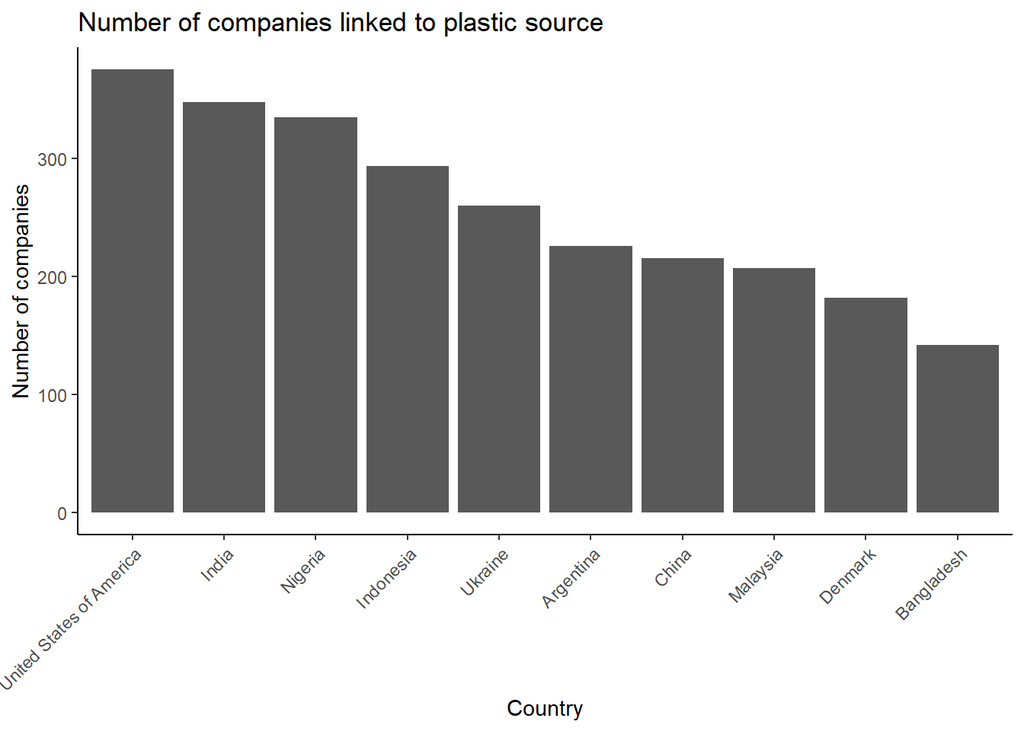

```r
## R
plastics_TP_2020 <- plastics %>%
  filter(year == 2020) %>%
  group_by(country) %>%
  count(country) %>%
  filter(n > 130)

ggplot(plastics_TP_2020, aes(x = reorder(country, -n), y = n)) +
  geom_col() +
  theme_classic() +
  theme(axis.text.x=element_text(angle=45, hjust=1)) +
  ggtitle("Number of companies linked to plastic source") +
  xlab("Country") +
  ylab("Number of companies")
```

This python code is something I have been trying to solve for the last week of class, but haven’t been able to solve. Even after following multiple guides, I don’t seem to be able to download and install Tcl for this code to knit properly. However, this graph that shows number of total plastic count for all countries is able to run on in Rstudio.

```python
##Python

# plastics_2020 = plastics.query('year == 2020')
#
# plastics_2020_T1 = plastics_2020.drop(columns=["num_events","volunteers","parent_company","year"])
# plastics_2020_T1 = plastics_2020_T1.groupby(["country"]).describe()
# plastics_2020_T1.head()
#
# plastics_2020_total = plastics_2020.filter(items = ["country","grand_total"])
# plastics_2020_total = plastics_2020_total.groupby(["country"]).sum()
# plastics_2020_total.plot.bar()
# plt.show()
```

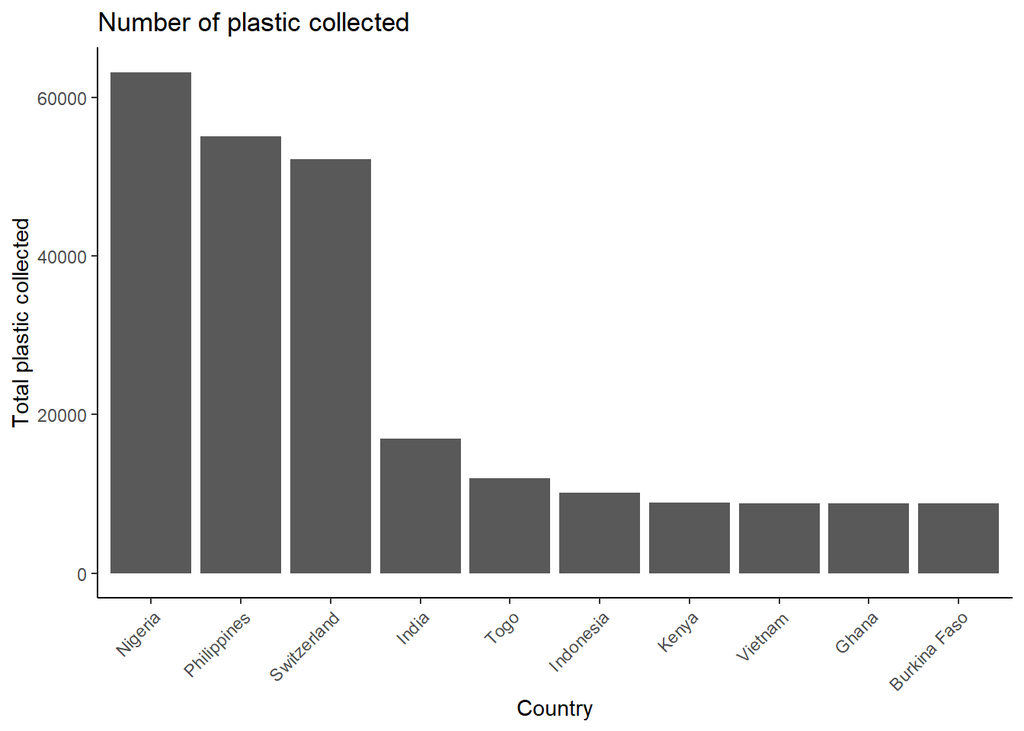

```r
## R
plastics_GT_2020 <- plastics %>%
  filter(year == 2020) %>%
  select(country,grand_total) %>%
  group_by(country) %>%
  summarize(Total = sum(grand_total)) %>%
  filter(Total > 8500)

ggplot(plastics_GT_2020, aes(x = reorder(country, -Total), y = Total)) +
  geom_col() +
  theme_classic() +
  theme(axis.text.x=element_text(angle=45, hjust=1)) +
  ggtitle("Number of plastic collected") +
  xlab("Country") +
  ylab("Total plastic collected")
```

Up to this point, I realized that the data can be extremely biased since it relies on feedback from plastic clean up organizations. Not every country is given the same resources to track and clean up plastic pollution.

The chart below shows the number of volunteers participated in each country versus the total amount of plastic collected. Nigeria, once again, is distinct from the other countries. Nigeria saw a large number of volunteers participating in the clean up and resulted in a high amount of plastics collected, a clear positive correlation between total amount of plastic collected to amount of volunteers. This correlation is observed with the USA and a majority of nations in the lower range.

However, Switzerland, Philippines, and China don’t seem to follow this correlation. This could be the case in low plastic collection rate for 2020 (in China’s case, which seems odd), or high plastic pollution in Switzerland and Philippines.

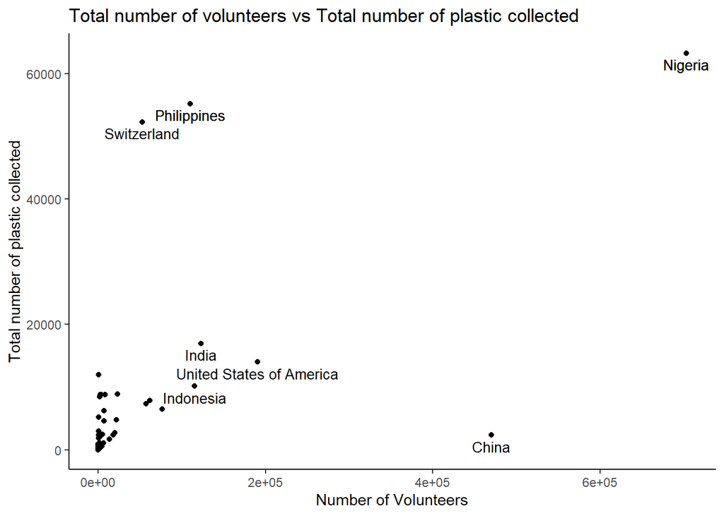

```r
## R
plastics_VC_2020 <- plastics %>%
  filter(year == 2020) %>%
  select(country, volunteers, grand_total) %>%
  group_by(country) %>%
  filter(volunteers != "NA", grand_total != "NA", country != "EMPTY") %>%
  summarise_all(sum)

ggplot(plastics_VC_2020, aes(x =volunteers,y=grand_total, label=country)) +
  geom_point() +
  geom_text(aes(label=ifelse(grand_total>20000,as.character(country),'')),size = 3.5, vjust = 1.5) +
  geom_text(aes(label=ifelse(volunteers>100000,as.character(country),'')),size = 3.5, vjust = 1.5) +
  theme_classic() +
  ggtitle("Total number of volunteers vs Total number of plastic collected") +
  xlab("Number of Volunteers") +
  ylab("Total number of plastic collected")
```

```r
## R
plastics_PT_2020 <- plastics %>%
  filter(year == 2020) %>%
  select(country,grand_total,hdpe,ldpe,o,pet,pp,ps,pvc) %>%
  group_by(country) %>%
  summarise_all(sum)

head(plastics_PT_2020)
```

```
## # A tibble: 6 × 9
##   country    grand_total  hdpe  ldpe     o   pet    pp    ps   pvc
##   <chr>            <dbl> <dbl> <dbl> <dbl> <dbl> <dbl> <dbl> <dbl>
## 1 Argentina         1086   132   141   212   144   263    62     4
## 2 Armenia              8     0     0     0     8     0     0     0
## 3 Australia         1668    33   222   898   141   361     3     6
## 4 Bangladesh        2383   376     2  1559   299    89    58     0
## 5 Benin              342     0     0     0   342     0     0     0
## 6 Brazil            2257   114   572   376   417   548   208    22
```

```r
plastics_PT_2020_percent <- plastics_PT_2020 %>%
  mutate(hdpe = (hdpe/grand_total)*100) %>%
  mutate(ldpe = (ldpe/grand_total)*100) %>%
  mutate(o = (o/grand_total)*100) %>%
  mutate(pet = (pet/grand_total)*100) %>%
  mutate(pp = (pp/grand_total)*100) %>%
  mutate(ps = (ps/grand_total)*100) %>%
  mutate(pvc = (pvc/grand_total)*100) %>%
  mutate(total_percent = (hdpe + ldpe + o + pet + pp + ps + pvc)) %>%
filter(grand_total != "NA") %>%
filter(grand_total > 8500) %>%
pivot_longer(
  cols = c(hdpe,ldpe,o,pet,pp,ps,pvc),
  names_to = "type",
  values_to = "Percent"
)

head(plastics_PT_2020_percent)
```

```
## # A tibble: 6 × 5
##   country      grand_total total_percent type  Percent
##   <chr>              <dbl>         <dbl> <chr>   <dbl>
## 1 Burkina Faso        8774           100 hdpe    3.04
## 2 Burkina Faso        8774           100 ldpe    0.228
## 3 Burkina Faso        8774           100 o      41.3
## 4 Burkina Faso        8774           100 pet    53.2
## 5 Burkina Faso        8774           100 pp      0.775
## 6 Burkina Faso        8774           100 ps      1.03
```

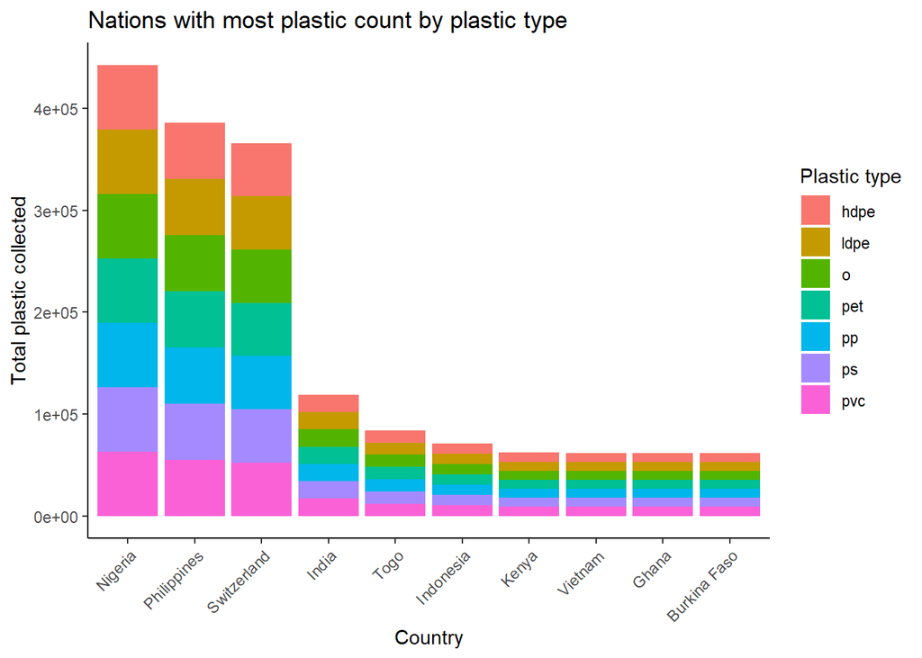

```r
ggplot(plastics_PT_2020_percent, aes(x=reorder(country, -grand_total), y = grand_total,fill=type)) +
  geom_col() +
  theme_classic() +
  theme(axis.text.x=element_text(angle=45, hjust=1)) +
  labs(fill = "Plastic type", x = "Country", y = "Total plastic collected", title = "Nations with most plastic count by plastic type")
```

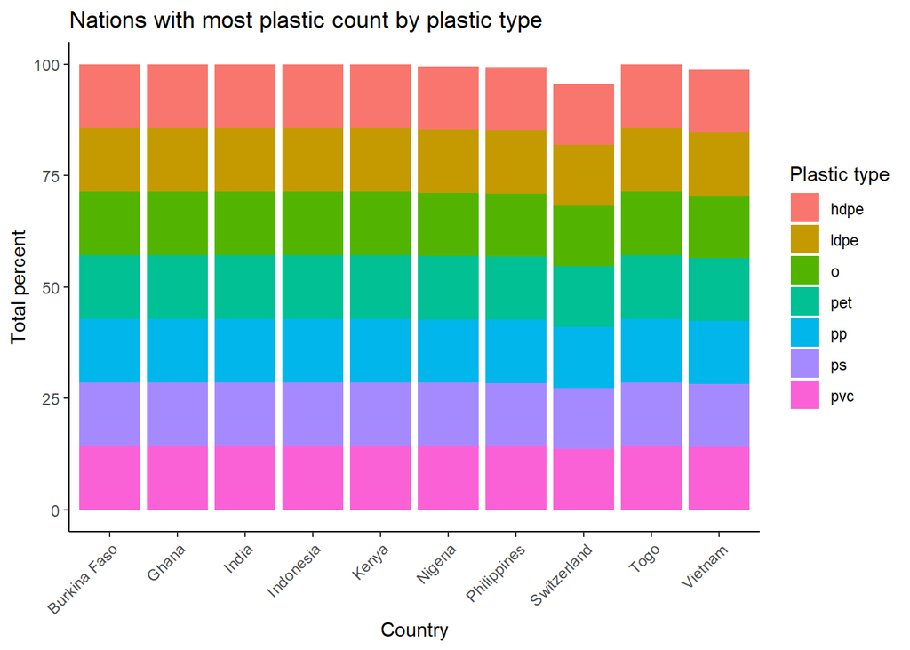

```r
ggplot(plastics_PT_2020_percent, aes(x=country,y= (total_percent/7), fill=type)) +
  geom_col() +
  theme_classic() +
  theme(axis.text.x=element_text(angle=45, hjust=1)) +
  labs(fill = "Plastic type", x = "Country", y = "Total percent", title = "Nations with most plastic count by plastic type")
```

Overall I enjoyed working on this final project.I wish I dived deeper into the data beforehand since I didn’t get to do much statistical analysis. While this project didn’t result in the goal of using python too much to analyze data, I found that R was much better suited for visual representation of data. With python, I liked the easy access of creating quick descriptions with PANDAS and sorting data. I’d imagine I would continue to use R for pure data analysis and sorting through experimental data, but I will love to keep learning to write programs with python to write code to supplement research work.